# Statistica inferenziale

## Regressione lineare semplice

Consideriamo il dataset *Betam*

```r
data(Betam,package = "Master")
Betam
```

|  | Conc | Area |
| --- | --- | --- |
| 1 | 32.90 | 526822 |
| 2 | 49.35 | 789297 |
| 3 | 65.80 | 1050565 |
| 4 | 82.25 | 1266479 |
| 5 | 98.70 | 1571215 |

Il dataset consiste di 5 righe e due colonne: le cinque righe corrispondono ciascuna a una coppia di punti x, y in cui x = Conc. e y = Area del picco di Betametasone misurata nel tracciato HPLC-UV dell’analisi condotta per la convalida del metodo (dosaggio del principio attivo betametasone in un collirio)

Diamo una occhiata ai dati in un grafico a dispersione

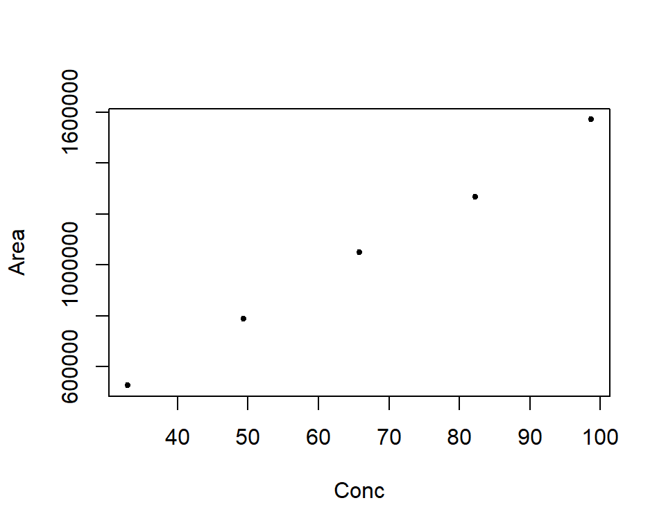

```r
plot(Area~Conc, data=Betam,pch=20,cex=0.8)
```

Cerchiamo di stimare la variabile *Area* (risposta) mediante un modello lineare nella variabile *Conc* (regressore). Supponiamo cioè che il risultato sperimentale $y_i$ possa essere modellizzato
$$\begin{equation}\label{eq:RegrLinSem}
y_i=\beta_0+\beta_1x_i+\epsilon_i, \quad i=1,\cdots,m \quad (m=5).
\end{equation}$$

dove $\epsilon_i \sim N(0,\sigma^2)$ e indipendenti (i.e. a due a due non correlati).

In **R** il modello () è definito mediante l’oggetto

```r
modello <- lm(Area ~ Conc, data = Betam)
```

in cui vengono registrati i principali risultati della regressione

```r
names(modello)
```

```
##  [1] "coefficients"  "residuals"     "effects"       "rank"
##  [5] "fitted.values" "assign"        "qr"            "df.residual"
##  [9] "xlevels"       "call"          "terms"         "model"
```

### Stima dei parametri e inferenza

I parametri del modello () da stimare sono $\beta_0, \beta_1$ e $\sigma^2$.

#### Stima dei parametri

Con il **metodo dei minimi quadrati** stimiamo $\beta_0$ e $\beta_1$, ossia determiniamo quella retta $\hat{\beta_0}+\hat{\beta_1}x_i$ per cui la somma dei quadrati dei residui è minima:
$$\begin{equation}\label{eq:ResLinSempl}
\sum_{i=1}^m(y_i-(\hat{\beta_0}+\hat{\beta_1}x_i))^2=\rm{min}_{b_0,b_1}\sum_{i=1}^m(y_i-(b_0+b_1x_i))^2.
\end{equation}$$
Si dimostra che i valori che soddisfano la () sono dati da
$$\begin{eqnarray*}
\hat{\beta_1}&=&\frac{\sum_{i=1}^m (x_i-\bar{x})(y_i-\bar{y})}{\sum_{i=1}^m(x_i-\bar{x})^2} \\
\hat{\beta_0}&=&\bar{y}-\hat{\beta}_1\bar{x}.
\end{eqnarray*}$$

Calcoliamo, per esercizio, questi parametri per l’esempio considerato

```r
x=Betam$Conc
y=Betam$Area
x.medio=mean(x)
y.medio=mean(y)
SS.x=sum((x-x.medio)^2) # variazione totale x

beta1=sum((x-x.medio)*(y-y.medio))/SS.x # stima beta 1
beta1
```

```
## [1] 15598.59
```

```r
beta0=y.medio-beta1*x.medio # stima beta 0
beta0
```

```
## [1] 14488.4
```

I parametri $\hat{\beta_0}$ e $\hat{\beta_1}$ sono registrati nell’oggetto *modello* e possono essere ottenuti direttamente con il comando

```r
modello$coefficients
```

```
## (Intercept)        Conc
##    14488.40    15598.59
```

Il grafico dei dati e della retta $\hat{\beta_0}+\hat{\beta_1}x_i$

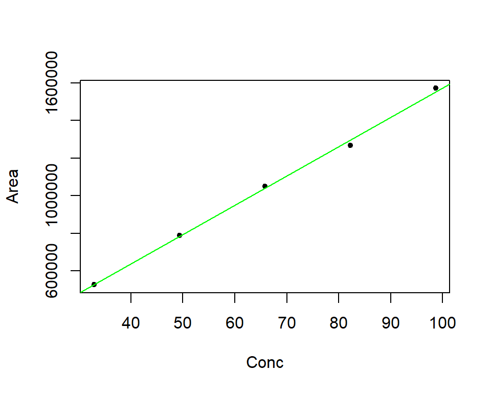

```r
plot(Area ~ Conc, data=Betam,pch=20)
abline(modello, col="green")
```

Indichiamo i residui con $e_i=y_i-(\hat{\beta_0}+\hat{\beta_1}x_i$). La quantità
$$\begin{equation*}
\frac{SS_{res}}{m-2}=\frac{\sum_{i=1}^me_i^2}{m-2}
\end{equation*}$$

è una stima di $\sigma^2$.

Calcoliamo per l’esempio considerato

```r
y.fit=beta0+beta1*x # valori previsti dal modello
e=y-y.fit # residui
SS.res=sum(e^2) # variazione Residui
m=nrow(Betam) # numero campioni
s.sq=SS.res/(m-2) # stima di sigma^2
s.sq
```

```
## [1] 458125235
```

```r
s=sqrt(s.sq) # errore standard Residuo
s
```

```
## [1] 21403.86
```

L’errore standard del Residuo può essere ottenuta direttamente dalla funzione

```r
sigma(modello)
```

```
## [1] 21403.86
```

così come i vettori *y.fit* (valori previsti dal modello) e *y-y.fit* (residui) precedentemente calcolati sono registrati nel modello *modello* e possono essere ottenuti con i comandi

```r
modello$fitted.values # y.fit
```

```
##         1         2         3         4         5
##  527682.0  784278.8 1040875.6 1297472.4 1554069.2
```

```r
modello$residuals # y-y.fit
```

```
##        1        2        3        4        5
##   -860.0   5018.2   9689.4 -30993.4  17145.8
```

#### Inferenza sui parametri

Pe poter fare inferenza sui parametri appena stimati dobbiamo conoscere la loro distribuzione. Si può dimostrare che
$$\begin{eqnarray}
\frac{\hat{\beta_0}-\beta_0}{s\sqrt{h}} &\sim& t(m-2) \label{eq:RegrStim0}\\
\frac{\hat{\beta_1}-\beta_1}{s\sqrt{1/S_{xx}}} &\sim& t(m-2) \label{eq:RegrStim1}\\
\frac{(n-2)s^2}{\sigma^2} &\sim& \chi^2(m-1)
\end{eqnarray}$$

dove $h=\frac{1}{m}+\frac{\bar{x}^2}{S_{xx}}$ e $S_{xx}=\sum_{i=1}^m(x_i-\bar{x})^2$.

Grazie alla () e alla () possiamo fare la seguente inferenza sui parametri

##### test ipotesi (t-test)

$$\begin{eqnarray*}
% \nonumber to remove numbering (before each equation)
H_0: \beta_0=0 \quad & \rm{vs} & \quad H_0: \beta_0\neq0 \\
H_0: \beta_1=0 \quad & \rm{vs} & \quad H_1: \beta_0\neq0
\end{eqnarray*}$$

Vediamo nel nostro esempio. Calcoliamo innanzitutto la deviazione (errore) standard di $\beta_0$

```r
h=1/m+x.medio^2/SS.x
ds.beta0=s*sqrt(h)
ds.beta0 # errore standard Intercetta
```

```
## [1] 28716.29
```

quindi la statistica $\frac{\hat{\beta_0}}{s\sqrt{h}}$ ($H_0: \beta_0=0$) e relativo p-value

```r
t0=beta0/ds.beta0
pt(q = -t0,df = m-2)+(1-pt(q = t0,df = m-2)) # p-value
```

```
## [1] 0.6486108
```

Il modello ha Intercetta non significativamente diversa da zero (p-value maggiore di 0.05).

Veniamo al parametro $\beta_1$

```r
ds.beta1=(s/sqrt(SS.x))
ds.beta1 # errore standard Pendenza
```

```
## [1] 411.4587
```

```r
t1=beta1/ds.beta1
pt(q = -t1,df = m-2)+(1-pt(q=t1,df=m-2)) # p-value
```

```
## [1] 4.037445e-05
```

Il modello ha Pendenza significativamente diversa da zero (p-value < 0.05)

Molti risultati fino ad ora descritti possono essere ottenuti con il comando

```r
summary(modello)
```

```
##
## Call:
## lm(formula = Area ~ Conc, data = Betam)
##
## Residuals:
##      1      2      3      4      5
##   -860   5018   9689 -30993  17146
##
## Coefficients:
##             Estimate Std. Error t value Pr(>|t|)
## (Intercept)  14488.4    28716.3   0.505    0.649
## Conc         15598.6      411.5  37.910 4.04e-05 ***
## ---
## Signif. codes:  0 '***' 0.001 '**' 0.01 '*' 0.05 '.' 0.1 ' ' 1
##
## Residual standard error: 21400 on 3 degrees of freedom
## Multiple R-squared:  0.9979, Adjusted R-squared:  0.9972
## F-statistic:  1437 on 1 and 3 DF,  p-value: 4.037e-05
```

Per la parte finale della visualizzazione precedente si veda il Paragrafo

##### intervallo confidenza

$$\begin{eqnarray*}
% \nonumber to remove numbering (before each equation)
\hat\beta_0 & \pm & t(\alpha/2,m-2)s\sqrt{h} \\
\hat\beta_1 & \pm & t(\alpha/2,m-2)s\sqrt{1/S_{xx}}
\end{eqnarray*}$$

Calcoliamo gli estremi degli intervalli di confidenza dell’Intercetta e della Pendenza nel nostro esempio

```r
beta0-qt(p = 0.025,df = m-2,lower.tail = FALSE)*ds.beta0
```

```
## [1] -76899.66
```

```r
beta0+qt(p = 0.025,df = m-2,lower.tail = FALSE)*ds.beta0
```

```
## [1] 105876.5
```

```r
beta1-qt(p = 0.025,df = m-2,lower.tail = FALSE)*ds.beta1
```

```
## [1] 14289.14
```

```r
beta1+qt(p = 0.025,df = m-2,lower.tail = FALSE)*ds.beta1
```

```
## [1] 16908.03
```

Gli intervalli di confidenza appena calcolati si posssono ottenere con la funzione

```r
confint(modello,level = 0.95)
```

```
##                 2.5 %    97.5 %
## (Intercept) -76899.66 105876.46
## Conc         14289.14  16908.03
```

Si osservi che lo zero appartiene all’intervallo di confidenza della Intercetta, infatti, coma abbiamo visto, non è significativamente diversa da zero

### Analisi della varianza

La *variazione totale* delle risposte y
$$\begin{equation}
SS_{tot}=\sum_{i=1}^{m}(y_i-\bar{y})^2
\end{equation}$$
può essere decomposta come segue
$$\begin{equation}
SS_{tot}=SS_{mod}+SS_{res},
\end{equation}$$
dove
$$\begin{equation}
SS_{mod}=\sum_{i=1}^{m}(\hat{y_i}-\bar{y})^2
\end{equation}$$

è la *variazione del modello* e $SS_{res}$ è la *variazione dei residui* già introdotta.

Calcoliamo la *variazione totale* e la *variazione modello* nel nostro esempio

```r
SS.tot=sum((y-y.medio)^2)
SS.mod=sum((y.fit-y.medio)^2)
SS.tot
```

```
## [1] 659793553407
```

```r
SS.res+SS.mod
```

```
## [1] 659793553407
```

Definiamo due indicatori della qualità dell’adattamento del modello ai dati.
Si chiama *Indice di determinazione* la proporzione della variazione totale spiegata dalla regressione lineare
$$\begin{equation}
R^2=1-\frac{SS_{res}}{SS_{tot}}
\end{equation}$$

e si dimostra essere uguale a $r^2_{y,x}$, correlazione tra $x$ e $y$.

```r
1-SS.res/SS.tot # R^2
```

```
## [1] 0.997917
```

Normalizzando le somme dei quadrati ottenendo le seguenti medie

$$\begin{eqnarray}
MS_{tot} &=& \frac{SS _{tot}}{m-1}\\
MS_{mod} &=& \frac {SS_{mod}}{(n+1)-1}\\
MS_{res} &=& \frac {SS_{res}}{m-(n+1)},
\end{eqnarray}$$

```r
MS.tot=SS.tot/(m-1)
MS.res=SS.res/(m-2)
```

Si chiama *Indice di determinazione aggiustato* il miglioramento della varianza residuale dato dal modello lineare
$$\begin{equation}
\bar{R}^2=\frac{MS_{tot}-MS_{res}}{MS_{tot}},
\end{equation}$$

dove $MS_{tot}=SS _{tot}/(m-1)$.

```r
1-MS.res/MS.tot # R^2 aggiustato
```

```
## [1] 0.9972226
```

La statistica
$$\begin{equation}\label{eq:FRegrLin}
F=\frac{MS_{mod}}{MS_{res}}
\end{equation}$$

sotto l’ipotesi nulla che $\beta_1=0$ (modello senza predittore, $Y=\beta_0$), è distribuita come $F(n,m-n-1)$.  
Rigettiamo l’ipotesi nulla per valori di $F$ maggiori del $(1-\alpha)$-esimo quantile della distribuzione $F$.

```r
SS.mod=sum((modello$fitted.values-mean(Betam$Area))^2)
MS.mod=SS.mod
F=MS.mod/MS.res # statistica F
F
```

```
## [1] 1437.203
```

```r
pf(q = F,df1 = 1,df2 = 3,lower.tail = FALSE) # p-value
```

```
## [1] 4.037445e-05
```

In questo caso essendo p-value < 0.05 rigettiamo l’ipotesi nulla. Si osservi che nel caso di regressione semplice il p-value del F-test coincide con il p-value del t-test coincidendo le ipotesi nulle dei 2 test.  
Nel caso della regressione multipla la questione è differente, si vedo il prossimo Paragrafo

Per avere l’analisi della varianza si usi il comando

```r
anova(modello)
```

|  | Df | Sum Sq | Mean Sq | F value | Pr(>F) |
| --- | --- | --- | --- | --- | --- |
| Conc | 1 | 658419177702 | 658419177702 | 1437.203 | 4.037445e-05 |
| Residuals | 3 | 1374375705 | 458125235 | NA | NA |

Anche nella parte finale di

```r
summary(modello)
```

```
##
## Call:
## lm(formula = Area ~ Conc, data = Betam)
##
## Residuals:
##      1      2      3      4      5
##   -860   5018   9689 -30993  17146
##
## Coefficients:
##             Estimate Std. Error t value Pr(>|t|)
## (Intercept)  14488.4    28716.3   0.505    0.649
## Conc         15598.6      411.5  37.910 4.04e-05 ***
## ---
## Signif. codes:  0 '***' 0.001 '**' 0.01 '*' 0.05 '.' 0.1 ' ' 1
##
## Residual standard error: 21400 on 3 degrees of freedom
## Multiple R-squared:  0.9979, Adjusted R-squared:  0.9972
## F-statistic:  1437 on 1 and 3 DF,  p-value: 4.037e-05
```

si trovano gli indici di determinazione, la stistica F e relativo p-value.

### Previsione

Fissato un valore $x_0$ della *Conc*, ad esempio $x_0=60$, vogliamo stimare il valore atteso $y_0$ dell’ *Area* per tale concentrazione. Il valore atteso stimato $\hat{y_0}$ è dato da
$$\begin{equation}
\hat{y_0}=\hat{\beta_0}+\hat{\beta_1}x_0
\end{equation}$$
Si può dimostrare che lo stimatore $y_0$ è distribuito come
$$\begin{equation}\label{eq:DistrRegrSempl}
\frac{\hat{y_0}-y_0}{s\sqrt{\frac{1}{m}+\frac{(x_0-\bar{x})^2}{S_{xx}}}}\sim t(m-2).
\end{equation}$$

Il valore $h_0=\frac{1}{m}+\frac{(x_0-\bar{x})^2}{S_{xx}}$ è chiamato valore leva (leverage) per il punto $x_0$ ed è un indicatore della qualità dello stimatore $y_0$. L’unico parametro controllabile da cui dipende la larghezza dell’intervallo di confidenza e quindi della previsione è $S_{xx}$. Più grande è tale valore migliori sono le stime. Poiché $S_{xx}$ misura lo spread delle $x$, è una buona idea quando si progetta un esperimento allargare il range delle $x$ il più possibile. Inoltre aumentando i valori delle $x$ verso gli estremi del range, si aumenta ulteriormente $S_{xx}$.

Si noti che a differenza dei modelli con un fattore in cui il valore ‘leva’ dipendeva dal numero di osservazioni nel punto, per la regressione lineare dipende anche dalla ‘posizione’ del punto rispetto alla media.

```r
x0=60
y0=beta0+beta1*x0 # stima
y0
```

```
## [1] 950403.8
```

```r
h0=1/m+(x0-x.medio)^2/SS.x # leverage
h0
```

```
## [1] 0.2124315
```

```r
ds.y0= s*sqrt(h0) # errore standard Previsione
ds.y0
```

```
## [1] 9865.102
```

I seguenti risultati si posssono ottenere con il comando

```r
predict(modello,newdata = data.frame(Conc=60),se=TRUE)
```

```
## $fit
##        1
## 950403.8
##
## $se.fit
## [1] 9865.102
##
## $df
## [1] 3
##
## $residual.scale
## [1] 21403.86
```

Grazie alla () possiamo fare inferenza per $y_0$:

$$\begin{equation*}
\hat{y_0}\pm t(\alpha/2,m-2)s\sqrt{\frac{1}{m}+\frac{(x_0-\bar{x})^2}{S_{xx}}}
\end{equation*}$$

```r
y0-qt(p = 0.975,df = m-2)*ds.y0
```

```
## [1] 919008.6
```

```r
y0+qt(p = 0.975,df = m-2)*ds.y0
```

```
## [1] 981798.9
```

L’intervallo di confidenza si ottiene con

```r
predict(modello,newdata = data.frame(Conc=c(60)),interval = "confidence")
```

```
##        fit      lwr      upr
## 1 950403.8 919008.6 981798.9
```

Per la previsioone puntuale bisogna aggiungere la variazione dell’errore
$$\begin{equation*}
\hat{y_0}\pm t(\alpha/2,m-2)s\sqrt{1+\frac{1}{m}+\frac{(x_0-\bar{x})^2}{S_{xx}}}
\end{equation*}$$

```r
predict(modello,newdata = data.frame(Conc=c(60)), interval = "prediction")
```

```
##        fit      lwr     upr
## 1 950403.8 875400.2 1025407
```

Grafico

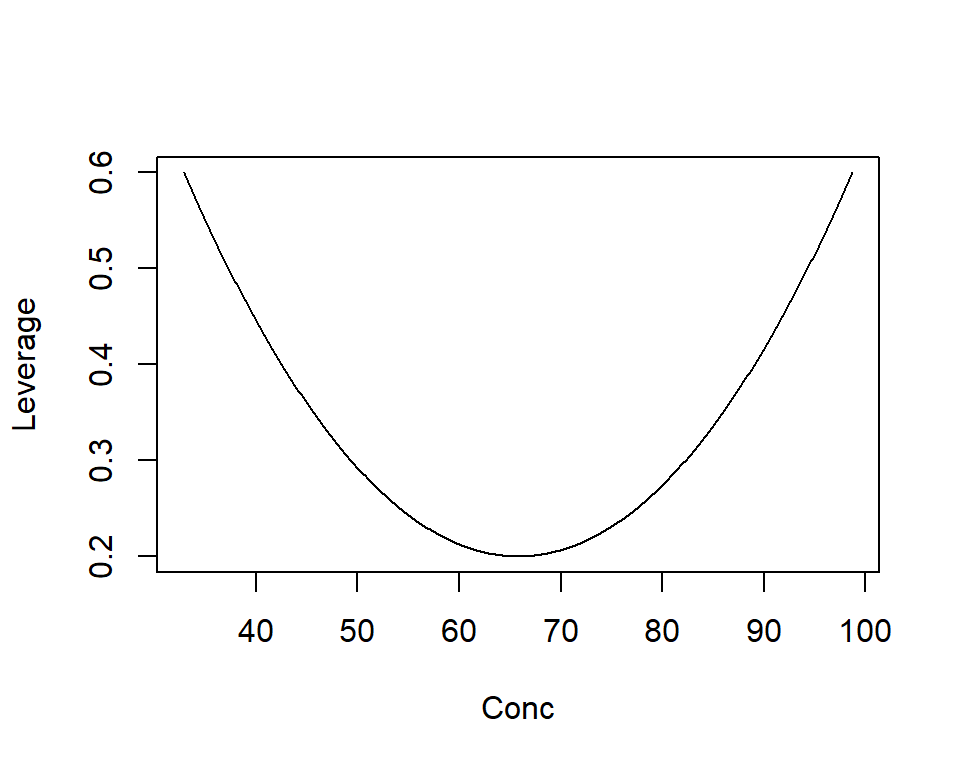

```r
X=seq(min(x),max(x),0.1)

h=1/m+(X-x.medio)^2/SS.x
plot(X,h,lty=1,type="l",col="black",
     xlab = "Conc",ylab="Leverage")
```

```r
Conf.medie=predict(modello,newdata=data.frame(Conc=X), level=.95, interval="confidence")
Conf.pt=predict(modello,newdata=data.frame(Conc=X), level=.95, interval="prediction")
```

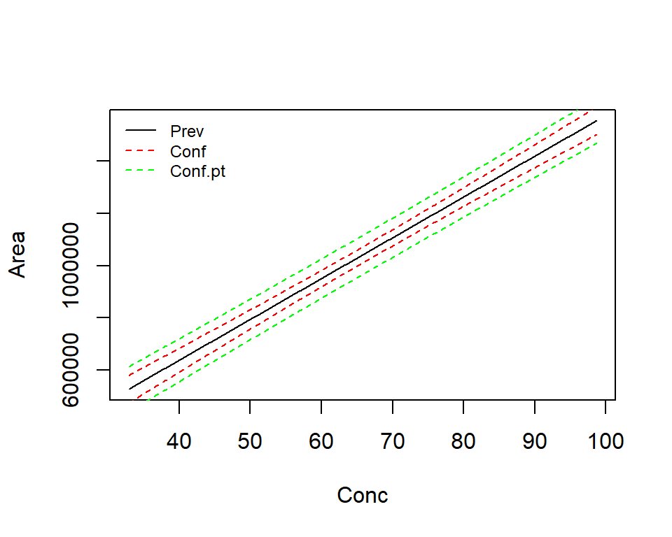

```r
plot(X,Conf.medie[,1],lty=1,type="l",col="black",xlab = "Conc",ylab="Area")
lines(X,Conf.medie[,2],lty=2,type="l",col="red")
lines(X,Conf.medie[,3],lty=2,type="l",col="red")
lines(X,Conf.pt[,2],lty=2,type="l",col="green")
lines(X,Conf.pt[,3],lty=2,type="l",col="green")
legend("topleft",legend = c("Prev","Conf","Conf.pt"),col=c("black","red","green"),
       lty=c(1,2,2),cex=0.75,bty="n")
```

Come si può vedere dalle figure precedenti le bande dell’intervallo di confidenza dipendono esclusivamente dal leverage e dall’ampiezza dell’errore $\sigma^2$.

### Diagnostica

Si può dimostrare che i residui $e_i=y_i-\hat{y_i}$ sono distribuiti
$$\begin{equation}\label{eq:DistrRegrSempl}
\frac{e_i}{s\sqrt{1-h_i}}\sim t(m-2),
\end{equation}$$

dove $h_i$ è il leverage in $x_i$. Si noti che $Var(\hat{y_i})+Var(e_i)=s^2$, si veda ().

Chiamiamo *residui standardizzati*
$$\begin{equation}
r_i=\frac{e_i}{s\sqrt{1-h_i}}
\end{equation}$$

```r
h=hatvalues(modello) # leverage
sd.res=s*sqrt(1-h) # deviazione standard residui
rstd=modello$residuals/sd.res # residui standardizzati
rstd
```

```
##           1           2           3           4           5
## -0.06352963  0.28022497  0.50612732 -1.73072511  1.26658882
```

I *residui standardizzati* si possono ottenere con il comando

```r
rstandard(modello)
```

```
##           1           2           3           4           5
## -0.06352963  0.28022497  0.50612732 -1.73072511  1.26658882
```

I *residui standardizzati* vengono spesso preferiti ai *residui* avendo varianza 1. Grandi differenze tra il comportamento dei *residui* e dei *residui standardizzati* si nota solo in caso di grandi valori di leva. In generale anche $Cor(r_i,r_j)$ tende ad essere piccola.

#### Analisi dei residui

Un’analisi preliminare può essere fatta mediante i quattro grafici (vedi Figura ) ottenuti con i comandi

```r
par(mfrow=c(2,2))
plot(fitted(modello),residuals(modello),col="red",pch=20,
     xlab="Fitted",ylab="Residui",main="Residui vs Fitted")
abline(h=0,lty=2)
car::qqPlot(rstandard(modello),col="red",pch=20, dist="t", df=3,xlab="t quantili",
            ylab="Residui standardizzati",main="Student QQ-plot",
            col.lines="Black",envelope=FALSE,grid=FALSE)
```

```
## [1] 4 5
```

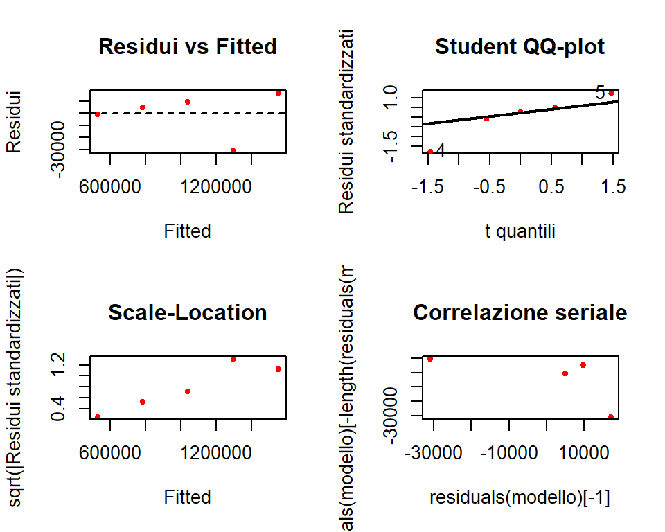

Grafici analisi dei residui

```r
plot(fitted(modello),sqrt(abs(rstandard(modello))),col="red",pch=20, xlab="Fitted",
     ylab="sqrt(|Residui standardizzati|)", main="Scale-Location")
plot(residuals(modello)[-1],residuals(modello)[-length(residuals(modello))],col="red",pch=20,
     main="Correlazione seriale")
```

```r
par(mfrow=c(1,1))
```

Dal primo grafico si vede la linearità, ossia se la funzione che lega la variabile risposta alle variabili indipendenti è di tipo lineare. I punti dovrebbero essere distribuiti in modo simmetrico intorno alla linea orizzontale con intercetta uguale a zero.  
Il secondo grafico verifica che i residui standardizzati seguano la distribuzione $t(m-2)$, vedi (). Se gli errori seguono la distribuzione $t(m-2)$ i punti dovrebbero concentrarsi intorno alla retta di coefficiente angolare $1$.  
Nel terzo grafico si vede un eventuale trend di dispersione, cosa che non dovrebbe accadere in caso di omoschedasticità degli errori.  
Con l’ultimo grafico si vede un’eventuale correlazione seriale degli errori.

Ora verifichiamo le ipotesi sui residui mediante opportuni test statistici. Verifichiamo che:  
**- la media dei residui non sia significativamente diversa da zero** con il seguente $test \ t$ sulla media

```r
t.test(rstandard(modello))
```

```
##
##  One Sample t-test
##
## data:  rstandard(modello)
## t = 0.10426, df = 4, p-value = 0.922
## alternative hypothesis: true mean is not equal to 0
## 95 percent confidence interval:
##  -1.326034  1.429509
## sample estimates:
##  mean of x
## 0.05173728
```

**- la normalità della distribuzione degli errori** con il test di Shapiro-Wilk

```r
shapiro.test(rstandard(modello))
```

```
##
##  Shapiro-Wilk normality test
##
## data:  rstandard(modello)
## W = 0.92087, p-value = 0.5356
```

in cui vengono confrontate due stime alternative di $\sigma^2$. L’ipotesi nulla è l’ipotesi di normalità.

**- l’omoschedasticità degli errori** con il test di Breusch-Pagan (occorre caricare il pacchetto *lmtest*)

```r
lmtest::bptest(modello)
```

```
##
##  studentized Breusch-Pagan test
##
## data:  modello
## BP = 1.8072, df = 1, p-value = 0.1789
```

**- la correlazione seriale** tramite il test di Durbin-Watson

```r
lmtest::dwtest(modello)
```

```
##
##  Durbin-Watson test
##
## data:  modello
## DW = 2.9314, p-value = 0.7327
## alternative hypothesis: true autocorrelation is greater than 0
```

Tutti i test di specificazione del modello hanno dato esito positivo, possiamo affermare che le ipotesi alla base del modello di regressione sono valide. Se anche uno solo dei test dà esito negativo (non normalità dei residui, eteroschedasticità, correlazione seriale) il metodo di stima del modello “non va più bene” e bisogna optare per altre soluzioni.

#### Outlier, punti di leva, punti influenti

Un *outlier* è un punto che non è ben interpolato dal modelo stimato. Se il residuo associato al punto è grande allora il punto è un outlier. Considerando che i residui standardizzati dovrebbero seguire una distribuzione $t$ di Student con $m-2$ gradi di libertà. Mettiamo in evidenza i valori dei residui standardizzati esterni alla banda di confidenza della distribuzione Student al $95\%$ (nel caso considerato $\pm$ 3.182) che possono ritenersi anormali.

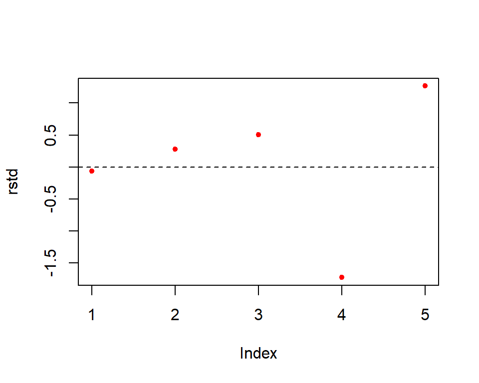

```r
plot(rstd,pch=20,col="red")
abline(h=qt(p = 0.025,df = 3,lower.tail = FALSE))
abline(h=-qt(p = 0.025,df = 3,lower.tail = FALSE))
abline(h=0,lty=2)
```

Un *punto di leva* è un punto “distante”. Un indicatore della leva di un punto è il valore di leva *leverage* $h_{i}$. Un punto con “alto” valore di leva ha un residuo con varianza “piccola” (cf. ()), cioè la retta deve passare “vicino” a questo punto. Vengono segnalati in generale come punti con elevato valore di leva i punti il cui leverage $h_{i}\geq\frac{2p}{m},p$ numero di parametri del modello (nel caso considerato $p=2$ e $h_{i}\geq$ 0.8).

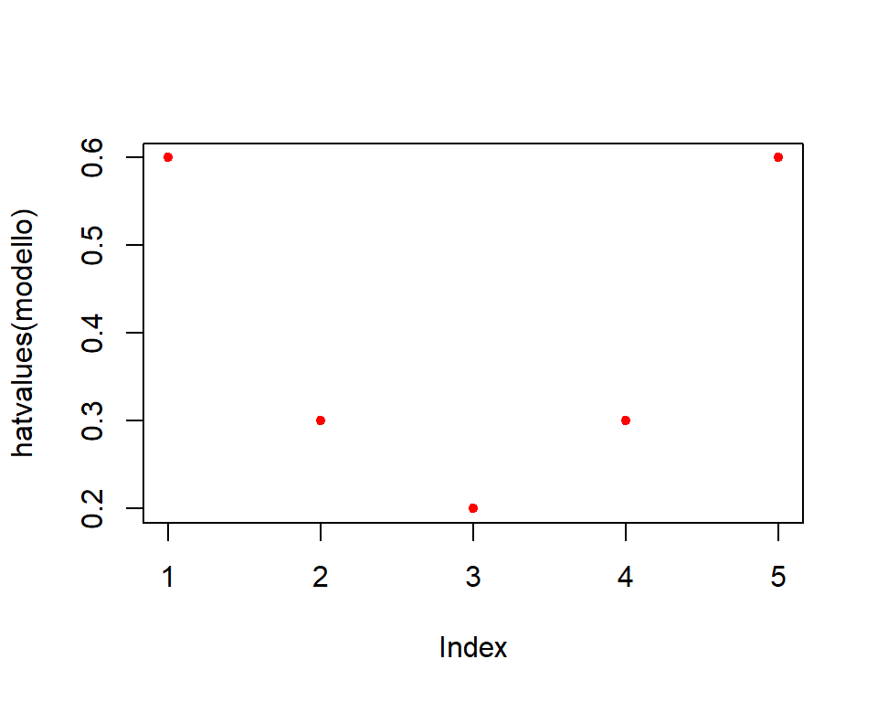

```r
plot(hatvalues(modello),pch=20,col="red")
abline(h=4/5)
```

Per un’analisi grafica dei punti influenti si può considerare il grafico seguente

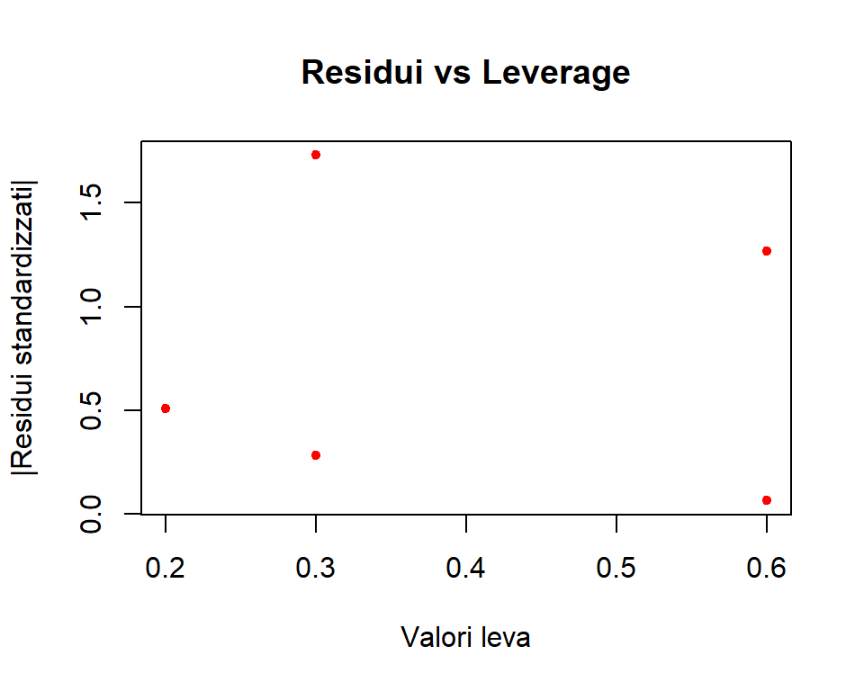

```r
plot(hatvalues(modello),abs(rstandard(modello)),main="Residui vs Leverage",xlab="Valori leva",
     ylab="|Residui standardizzati|", col="Red",pch=20)
abline(v=4/m)
abline(h=qt(p = 0.025,df = 3,lower.tail = FALSE))
```

## Regressione lineare multipla

Consideriamo il dataset *Van_Deemter*

```r
data(Van_Deemter,package="Master")
Van_Deemter
```

|  | x1 | x2 | y |
| --- | --- | --- | --- |
| 1 | 0.17807183 | 5.62 | 11.55 |
| 2 | 0.14245747 | 7.02 | 11.13 |
| 3 | 0.07122873 | 14.04 | 12.26 |
| 4 | 0.03561437 | 28.08 | 17.17 |
| 5 | 0.02374291 | 42.12 | 22.72 |
| 6 | 0.01780718 | 56.16 | 28.80 |
| 7 | 0.01424575 | 70.20 | 34.78 |
| 8 | 0.01236610 | 80.87 | 39.01 |

I dataset consiste di 8 righe e 3 colonne: ogni riga corrisponde alla misura misura dell’HETP (variabile $y$) per una determinata velocità lineare u (variabile $x_2$) e per il suo inverso 1/u (variabile $x_1$).
Per l’equazione di *Van Deemter* abbiamo che
$$\begin{equation}\label{eq:vandeemter}
H=\frac{a}{u}+bu+c
\end{equation}$$
Possiamo quindi modellizzare la ()
$$\begin{equation}\label{eq:ModLinMult}
y_i=\beta_0+\beta_1x_{i1}+\beta_2x_{i2}+\epsilon_i, \qquad i=1,\dots,m \quad (m=8),
\end{equation}$$
dove $\epsilon_i\sim N(0,\sigma^2)$ a due a due non correlate. Possiamo scrivere il modello () in forma matriciale:
$$\begin{equation}\label{eq:ModLinMultMatr}
\bf{y}=\bf{X}\boldsymbol{\beta}+\boldsymbol{\sigma}
\end{equation}$$
dove
$$\begin{equation*}
\bf{y}=\left(
\begin{array}{c}
y_1 \\
\vdots \\
y_m \\
\end{array}
\right),\qquad
\bf{X}=\left(
\begin{array}{cccc}
1 & x_{11} & x_{12} \\
\vdots & \vdots & \vdots \\
1 & x_{m1} & x_{m2} \\
\end{array}
\right),\qquad
\boldsymbol{\beta}=\left(
\begin{array}{c}
\beta_0 \\
\beta_1 \\
\beta_2 \\
\end{array}
\right) \qquad \rm{e} \qquad
\boldsymbol{\epsilon}
=\left(
\begin{array}{c}
\epsilon_1 \\
\vdots \\
\epsilon_m\\
\end{array}
\right).
\end{equation*}$$

Assumiamo che:

1. $\bf{X}$ sia una matrice (non stocastica) di rango $3$, ciò significa che ci sono almeno 3 righe e le 3 colonne (i regressori) siano linearmente indipendenti
2. l’errore $\boldsymbol{\epsilon}$ sia una variabile aleatoria tale che $\boldsymbol{\epsilon} \sim N(\bf{0},\sigma^2 \bf{I})$ (normalità) e $\mathbb{E}(\boldsymbol{\epsilon} \boldsymbol{\epsilon}^t) = \sigma^2\bf{I}$ (indipendenza e omoschedasticità).

Come abbiamo già visto nel paragrafo predente queste ipotesi vanno verificate mediante opportuni test statistici.

In **R** il modello () è definito mediante

```r
modello=lm(y~x1+x2,data=Van_Deemter)
```

### Stima dei parametri e inferenza

I parametri del modello () sono $\beta_0$, $\beta_1$, $\beta_2$ e $\sigma^2$.

#### Stima dei parametri

Per la stima dei parametri $\beta_0$, $\beta_1$, $\beta_2$ si usa il **metodo dei minimi quadrati**, ossia si minimizza la somma dei quadrati dei residui:
$$\begin{equation}\label{eq:SommaQuadREs}
(\mathbf{y-Xb})^t(\mathbf{y-Xb}) = \sum_{i=1}^m(y_i-(b_0+b_1x_{i1}+b_nx_{i2})).
\end{equation}$$
Si dimostra che i valori che minimizzano la () sono dati da:
$$\begin{equation*}
\hat{\boldsymbol{\beta}}=(\bf{X}^t\bf{X})^{-1}\bf{X}^t\bf{y}.
\end{equation*}$$

Osserviamo che l’assunzione 1. implica l’invertibilità della *matrice di informazione* $\bf{X}^t\bf{X}$ (chiamiamo *matrice di dispersione* la matrice $(\bf{X}^t\bf{X})^{-1}$).

```r
X=cbind(Interc=rep(1,8),Van_Deemter[,1:2])
X=as.matrix(X)
y=as.matrix(Van_Deemter[,3])
beta=solve(t(X)%*%X)%*%t(X)%*%y; beta
```

```
##              [,1]
## Interc  4.1966902
## x1     27.7796950
## x2      0.4277422
```

I parametri $\hat{\beta_0}, \hat{\beta_1}$ e $\hat{\beta_2}$ sono registrati nell’oggetto *modello* e possono essere ottenuti con il comando

```r
modello$coefficients
```

```
## (Intercept)          x1          x2
##   4.1966902  27.7796950   0.4277422
```

e i valori $\hat{y}_i=\beta_0+\beta_1x_{i1}+\beta_2x_{i2}$ ($\hat{\bf{y}}=\bf{X}\boldsymbol{\beta}$)

```r
X%*%beta
```

```
##       [,1]
## 1 11.54738
## 2 11.15687
## 3 12.18090
## 4 17.19705
## 5 22.87276
## 6 28.71337
## 7 34.61994
## 8 39.13173
```

si ottengono con il comando con il comando

```r
modello$fitted.values
```

```
##        1        2        3        4        5        6        7        8
## 11.54738 11.15687 12.18090 17.19705 22.87276 28.71337 34.61994 39.13173
```

Dalla () otteniamo il grafico di $H$ in funzione di $u$, Figura

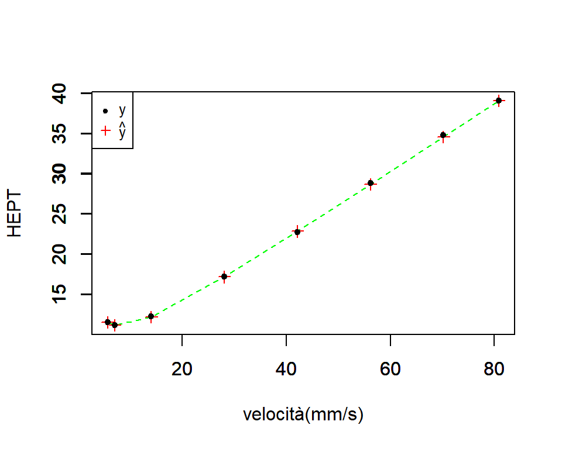

Equazione di Van Deemter

```r
plot(modello$fitted.values~Van_Deemter$x2,type="l",col="green",ylab="HEPT",
     xlab="velocità(mm/s)",lty=2)
par(new=TRUE)
plot(modello$fitted.values~Van_Deemter$x2,col="red",ylab="",xlab="",pch=3)
par(new=TRUE)
plot(Van_Deemter$y~Van_Deemter$x2,pch=20,ylab="",xlab="")
legend("topleft",legend = expression(y,hat(y)),pch=c(20,3),col=c("black","red"),cex=0.8)
```

Si può inoltre dimostrare che
$$\begin{equation}\label{eq:CovB}
Cov(\hat{\boldsymbol{\beta}})= \sigma^2(\bf{X}^t{X})^{-1}
\end{equation}$$
Quindi, in particolare, abbiamo che
$$\begin{equation*}
Var(\hat \beta_j)=\sigma^2 d_{jj}
\end{equation*}$$

dove $d_{jj}$ è l’elemento di posto $(j,j)$ (elemento posto $j$ diagonale) della matrice di dispersione $(\bf{X}^t\bf{X})^{-1}$.  
Nel nostro esempio numerico la matrice di dispersione è

```r
solve(t(X)%*%X)
```

```
##              Interc          x1          x2
## Interc   2.29934278 -14.6471396 -0.03333196
## x1     -14.64713956 111.1882328  0.20413511
## x2      -0.03333196   0.2041351  0.00054421
```

Osserviamo che i parametri non sono tra di loro indipendenti (la matrice ha valori non nulli fuori dalla diagonale). Questo è dovuto al fatto che le variabili $x_1$ e $x_2$ non sono indipendenti.

Una stima della varianza $\sigma^2$ si ottiene da:
$$\begin{equation*}
s^2=\frac{(\bf{y}-\hat{\bf{y}})^t(\bf{y}-\hat{\bf{y}})}{m-3}.
\end{equation*}$$

Si osservi che i gradi di libertà dell’errore standard del Residuo sono dati dal numero di righe $m$ meno il numero di parametri da stimare 3.  
L’errore standard del Residuo può essere ottenuto direttamente dalla funzione

```r
sigma(modello)
```

```
## [1] 0.125695
```

#### Inferenza sui parametri

Si può dimostrare che gli stimatori $\hat{\beta_j}$ e $s^2$ hanno le seguenti distribuzioni:
$$\begin{eqnarray}
\frac{\hat{\beta_j}_j-\beta_j}{\sqrt{s^2d_{jj}}} & \sim & t(m-3) \label{eq:RegrStimJ} \\
\frac{(m-3)s^2}{\sigma^2} & \sim & \chi(m-3),
\end{eqnarray}$$

Grazie alla () possiamo fare la seguente inferenza sui parametri (si osservi che deve essere $m>3$ per avere almeno un grado di libertà. Per $m=3$ è possibile stimare i parametri non fare inferenza)

- test ipotesi (t-test)
  $$\begin{eqnarray*}
  H_0: \beta_j=0 \quad & \rm{vs} & \quad H_0: \beta_j\neq0
  \end{eqnarray*}$$
  Con la funzione *summary* otteniamo la seguente visualizzazione

```r
summary(modello)
```

```
##
## Call:
## lm(formula = y ~ x1 + x2, data = Van_Deemter)
##
## Residuals:
##         1         2         3         4         5         6         7
##  0.002617 -0.026866  0.079097 -0.027048 -0.152763  0.086629  0.160064
##         8
## -0.121730
##
## Coefficients:
##              Estimate Std. Error t value Pr(>|t|)
## (Intercept)  4.196690   0.190599   22.02 3.59e-06 ***
## x1          27.779695   1.325401   20.96 4.58e-06 ***
## x2           0.427742   0.002932  145.88 2.87e-10 ***
## ---
## Signif. codes:  0 '***' 0.001 '**' 0.01 '*' 0.05 '.' 0.1 ' ' 1
##
## Residual standard error: 0.1257 on 5 degrees of freedom
## Multiple R-squared:  0.9999, Adjusted R-squared:  0.9999
## F-statistic: 2.673e+04 on 2 and 5 DF,  p-value: 8.457e-11
```

in cui otteniamo una breve statistica descrittiva dei residui, i valori delle stime $\hat{\beta_j}$, le varianze (errori standard) ($\sqrt{s^2d_{jj}}$) degli stimatori $\hat{\beta_j}$, le statistiche $\frac{\hat{\beta_j}}{\sqrt{s^2d{jj}}}$ e i rispettivi $t$-$test$ ($H_0:\beta_j=0 \,\, vs \,\, H_1:\beta_j\neq0$)).  
Si noti che il $t$-$test$ viene fatto sul singolo parametro assumendo che gli altri predittori siano già inclusi nel modello. Se per esempio ci sono più predittori statisticamente nulli non possiamo pensare di eliminarli tutti contemporaneamente (potrebbe succedere che nel nuovo modello a cui è stato tolto uno di questi predittori, uno o più predittori che risultavano statisticamente nulli nel modello iniziale ora non lo siano più). Possiamo eliminare un predittore statisticamente nullo per volta, ad esempio quello il cui $t$-$test$ presenta il $p$-$value$ più elevato (*backward elimination*), e poi stimare il nuovo modello senza quel predittore e verificare se ci sono ancora parametri statisticamente nulli.

In questo caso si vede che i $t$-$test$ per ogni regressore rifiutano l’ipotesi nulla, i.e. l’essere uguale a zero.

- intervallo confidenza
  $$\begin{eqnarray*}
  \hat\beta_j & \pm & t(\alpha/2,m-3)s\sqrt{d_{jj}}
  \end{eqnarray*}$$
  Con la funzione *confint* otteniamo l’intervallo di confidenza per la stima dei parametri

```r
confint(modello)
```

```
##                  2.5 %     97.5 %
## (Intercept)  3.7067409  4.6866396
## x1          24.3726432 31.1867468
## x2           0.4202046  0.4352798
```

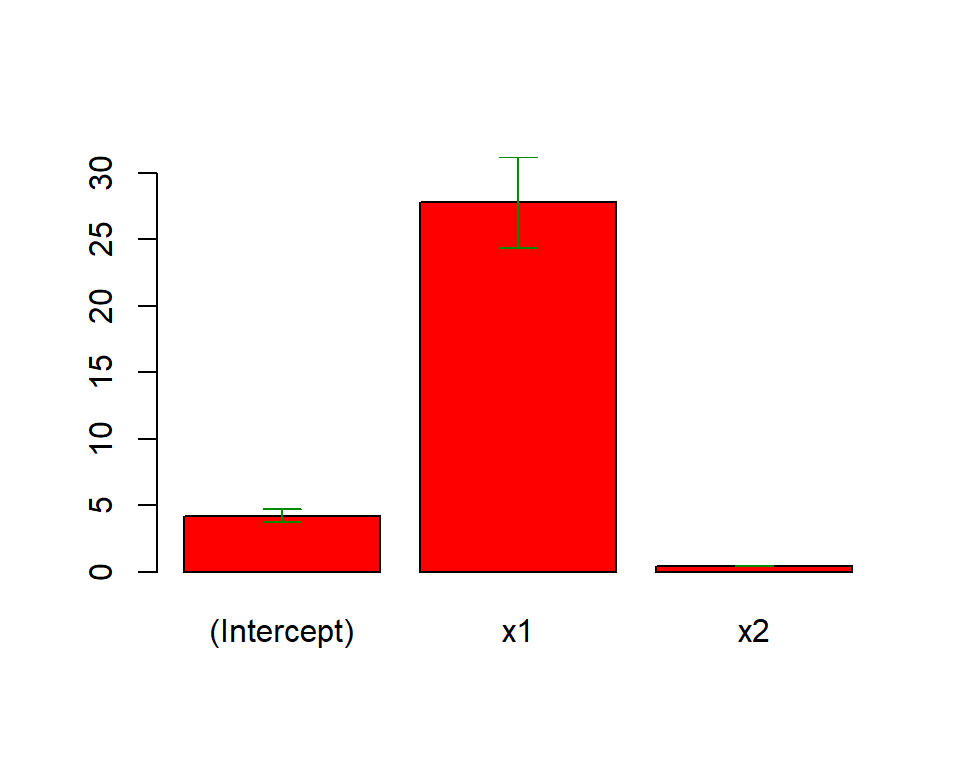

Parametri del modello

```r
p=barplot(modello$coefficients,col="red",
          ylim=c(min(0,min(confint(modello)[,1])),max(0,max(confint(modello)[,2]))))
arrows(x0=p[1],y0 =confint(modello)[1,1],x1=p[1],y1=confint(modello)[1,2],
       length = 0.1,angle = 90,code = 3,col = "green4" )
arrows(x0=p[2],y0 =confint(modello)[2,1],x1=p[2],y1=confint(modello)[2,2],
       length = 0.1,angle = 90,code = 3,col = "green4" )
arrows(x0=p[3],y0 =confint(modello)[3,1],x1=p[3],y1=confint(modello)[3,2],
       length = 0.1,angle = 90,code = 3,col = "green4" )
```

### Analisi della varianza

Ragionando in maniera analoga al caso della regressione lineare semplice si può dimostrare che per le seguenti somme di quadrati, che chiameremo *variazione dei residui*
$$\begin{equation}
SS_{res}=\sum_{i=1}^{m}(y_i-\hat{y_i})^2
\end{equation}$$
e *variazione del modello*
$$\begin{equation}
SS_{mod}=\sum_{i=1}^{m}(\hat{y_i}-\bar{y})^2
\end{equation}$$
vale la seguente
$$\begin{equation}
SS_{res}+SS_{mod}=\sum_{i=1}^{m}(y_i-\bar{y})^2=SS_{tot}.
\end{equation}$$
Normalizziamo le somme dei quadrati ottenendo le seguenti medie
$$\begin{eqnarray}
MS_{res} &=& \frac {SS_{res}}{m-3}\\
MS_{mod} &=& \frac {SS_{mod}}{2}.
\end{eqnarray}$$
Si ha che la statistica
$$\begin{equation}\label{eq:FRegrLin}
F=\frac{MS_{mod}}{MS_{res}}
\end{equation}$$

sotto l’ipotesi nulla che $\beta_1=\beta_2=0$ (modello senza predittori, $y=\beta_0$), è distribuita come $F(2,m-3)$. Rigettiamo l’ipotesi nulla per valori di $F$ maggiori del $(1-\alpha)$-esimo quantile della distribuzione $F$.

Definiamo due indicatori della qualità dell’adattamento del modello ai dati.
Si chiama *Indice di determinazione* la proporzione della variazione totale spiegata dalla regressione lineare
$$\begin{equation}
R^2=1-\frac{SS_{res}}{SS_{tot}}
\end{equation}$$
e si dimostra essere uguale a $r^2_{\bf{y},\hat{\bf{y}}}$, il quadrato della correlazione tra i valori osservati e i valori stimati dal modello.
Si chiama *Indice di determinazione aggiustato* il miglioramento della varianza residuale dato dal modello lineare
$$\begin{equation}
\bar{R}^2=\frac{MS_{tot}-MS_{res}}{MS_{tot}},
\end{equation}$$

dove $MS_{tot}=SS _{tot}/(m-1)$. Nella regressione multipla è opportuno considerare $\bar{R}^2$ in quanto tiene conto anche del numero dei predittori inclusi nel modello. Va quindi a bilanciare due obiettivi contrapposti: quello di ottenere un buon modello e quello di avere un modello semplice, che non contenga troppi predittori.

Per l’analisi della varianza si veda la parte finale della visualizzazione di

```r
summary(modello)
```

```
##
## Call:
## lm(formula = y ~ x1 + x2, data = Van_Deemter)
##
## Residuals:
##         1         2         3         4         5         6         7
##  0.002617 -0.026866  0.079097 -0.027048 -0.152763  0.086629  0.160064
##         8
## -0.121730
##
## Coefficients:
##              Estimate Std. Error t value Pr(>|t|)
## (Intercept)  4.196690   0.190599   22.02 3.59e-06 ***
## x1          27.779695   1.325401   20.96 4.58e-06 ***
## x2           0.427742   0.002932  145.88 2.87e-10 ***
## ---
## Signif. codes:  0 '***' 0.001 '**' 0.01 '*' 0.05 '.' 0.1 ' ' 1
##
## Residual standard error: 0.1257 on 5 degrees of freedom
## Multiple R-squared:  0.9999, Adjusted R-squared:  0.9999
## F-statistic: 2.673e+04 on 2 and 5 DF,  p-value: 8.457e-11
```

in cui si trovano gli indici di detereminazione, la statistica $F$ e relativo *p-value*.  
In questo caso possimao rigettare l’ipotesi nulla che entrambi i parametri $\beta_1$ e $\beta_2$ siano nulli  
(*p-value* << 0.05).

### Previsione

Fissiamo un valore un predittore $\mathbf{x}_0=(1,x_1^0,x_2^0)$ (ad esempio $x_1=1/20, x_2=20$: i.e. $u=20$) vogliamo stimare il valore atteso $y_0$ dell’HETP per tale velocità lineare.
Il valore atteso stimato $\hat{y}_0$ è dato da
$$\begin{equation}
\hat{y}_0=\mathbf{x}_0 \boldsymbol{\beta}
\end{equation}$$

```r
x0=matrix(data = c(1,1/20,20),nrow = 1)
beta=matrix(data = modello$coefficients,ncol=1)
x0%*%(beta) # valore previsto in x0
```

```
##          [,1]
## [1,] 14.14052
```

Si può dimostrare che
$$\begin{equation}\label{eq:distr_prev}
\frac{\hat{y}_0 - y_0}{s\sqrt{\bf{x}_0(X^tX)^{-1}\bf{x}_0^t}} \sim t(m-3).
\end{equation}$$

Il valore $h_0=\bf{x}_0(X^tX)^{-1}\bf{x}_0^t$ è chiamato valore leva (leverage) per il punto $\bf{x}_0$, si vedano a tal propoposito le osservazioni fatte nel paragrafo della regressione semplice.

```r
h0=x0%*%solve(t(X)%*%X)%*%t(x0);h0 # leverage in x0
```

```
##           [,1]
## [1,] 0.4052753
```

L’errore standard della Previsione è quindi

```r
sigma(modello)*sqrt(h0)
```

```
##            [,1]
## [1,] 0.08001897
```

I precedenti risultati possono essere ottenuti con il comando

```r
x0=data.frame(x1=1/20,x2=20)
predict(modello,newdata = x0,se=TRUE)
```

```
## $fit
##        1
## 14.14052
##
## $se.fit
## [1] 0.08001897
##
## $df
## [1] 5
##
## $residual.scale
## [1] 0.125695
```

Grazie alla () possiamo determinare l’intervallo di confidenza per $y_0$:
$$\begin{equation*}
\hat y_0 \pm t(\alpha/2,m-3)s\sqrt{h_0},
\end{equation*}$$

```r
predict(modello,newdata = x0,interval = "confidence")
```

```
##        fit      lwr      upr
## 1 14.14052 13.93482 14.34621
```

L’intervallo di confidenza del valore puntuale previsto è data da
$$\begin{equation*}
\hat y_0 \pm t(\alpha/2,m-3)s\sqrt{1+h_0},
\end{equation*}$$

a cui abbiamo aggiunto, rispeto al caso precedente, anche la variazione dell’errore

```r
predict(modello,newdata = x0,interval = "prediction")
```

```
##        fit      lwr      upr
## 1 14.14052 13.75749 14.52355
```